# UFC Data

Zackery Lignore

11/14/2019

# The Data

I explored kaggle.com to find a dataset that was interesting to me as well as manageable to work with. The UFC data caught my eye immediately. Most sports data is packed full of statistical values making them a good choice to work with. The dataset that I sourced had 145 columns of various data inputs ranging from names and locations to average number of times the opponent attempted a take down and the measure of arm length per fighter. I did not find one specific problem to address when looking at the data as a whole. Instead, I explored the data until interesting variables were found. The only package that I used was tidyverse. This is needed to use dplyer to manipulate the dataset. The original dataset can be found at https://www.kaggle.com/rajeevw/ufcdata along with other csv files of raw data that I did not use in the making of this project.

```r
# The tidyverse package is loaded in order to use Dplyer tools on the dataset.

library(tidyverse)
```

The original data imported below had 145 columns, many of which I did not use. Throughout the project I created other columns that do not exist in the original data. In the code below I import the data, create all the added variable that I will use later, then select only the variables that I want, 46 columns. I also omit all input that is missing data. Most of these were fighters listed without having had a fight yet. They were omitted to allow for true computations of the numerical data. The data is stored for both red and blue corners. Because the input is the latest information, a fighter can have different stats following each fight. The latest fight will display the current information.

```r
# The data is loaded into the markdown file and all entries missing data are omitted from the set. New columns are created to generate further summaries. Finally, the select function is used to get the desired data.

data <- read.csv("../Data Sets/ufc_data.csv")
data <- data %>% na.omit() %>% mutate(B_win_pct = B_wins/(B_losses + B_wins),
                                      R_win_pct = R_wins/(R_losses + R_wins),
                                      R_RH = (R_Reach_cms)/(R_Height_cms),
                                      B_RH = (B_Reach_cms)/(B_Height_cms),
                                      R_Total_fights = R_wins + R_losses,
                                      B_Total_fights = B_wins + B_losses,
                                      R_strike_pct = (R_avg_TOTAL_STR_landed/R_avg_TOTAL_STR_att),
                                      B_strike_pct = (B_avg_TOTAL_STR_landed/B_avg_TOTAL_STR_att)) %>%
                                      select(R_fighter, B_fighter, Referee, date, location, Winner, weight_class,
                                      no_of_rounds, B_avg_TOTAL_STR_att, B_avg_TOTAL_STR_landed,
                                      R_avg_TOTAL_STR_att, R_avg_TOTAL_STR_landed, B_losses, R_losses,
                                      B_wins, R_wins, B_total_rounds_fought, R_total_rounds_fought,
                                      B_win_by_Decision_Majority, B_win_by_Decision_Split,
                                      B_win_by_Decision_Unanimous, B_win_by_KO.TKO, B_win_by_Submission,
                                      B_win_by_TKO_Doctor_Stoppage, R_win_by_Decision_Majority,
                                      R_win_by_Decision_Split, R_win_by_Decision_Unanimous,
                                      R_win_by_KO.TKO, R_win_by_Submission, R_win_by_TKO_Doctor_Stoppage,
                                      B_Stance, R_Stance, B_Height_cms, R_Height_cms, B_Reach_cms,
                                      R_Reach_cms, B_age, R_age, B_win_pct, R_win_pct, R_RH, B_RH,
                                      R_Total_fights, B_Total_fights, R_strike_pct, B_strike_pct)
```

# Gender

The biggest distinction between the data is that of gender. Sometimes the data between each gender agrees together, however, most of the time there is a stark contrast between the data of men’s and women’s fights and stats. The following code separates the men’s fights by their respective weight class calling the new dataset M_data. The same is done for the women’s weight classes creating the dataset F_data.

```r
# Creates new dataset with men's fights only.

M_data <- data %>% filter(weight_class %in%
                                          c("Bantamweight", "Catch Weight", "Featherweight", "Flyweight",
                                              "Heavyweight", "Light Heavyweight", "Lightweight", "Middleweight",
                                              "Open Weight", "Welterweight"))
```

```r
# Creates new dataset with women's fights only.

F_data <- data %>% filter(weight_class %in% c("Women's Strawweight", "Women's Flyweight",
"Women's Featherweight", "Women's Bantamweight"))
```

## Fight Decisions

The first curiosity of mine was how do all the fights end? The following table shows that men’s fights are most likely to end by knockout or technical knockout. The least common way to end is by majority decision. This data combines the variables from red and blue corners to find the total.

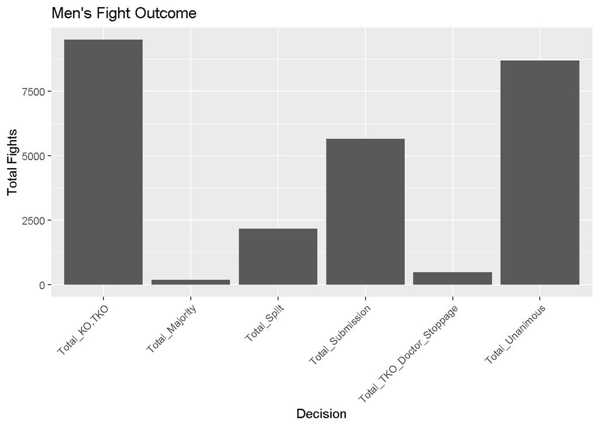

```r
# Creates a data frame with the total number of fights and how they were decided for the Men's data. Then graphs the findings.

M_type_of_win <- M_data %>%  summarise(Total_Majority = sum(B_win_by_Decision_Majority) +
                      sum(R_win_by_Decision_Majority),
                      Total_Split = sum(B_win_by_Decision_Split) + sum(R_win_by_Decision_Split),
                      Total_Unanimous = sum(B_win_by_Decision_Unanimous) + sum(R_win_by_Decision_Unanimous),
                      Total_KO.TKO = sum(B_win_by_KO.TKO) + sum(R_win_by_KO.TKO),
                      Total_Submission = sum(B_win_by_Submission) + sum(R_win_by_Submission),
                      Total_TKO_Doctor_Stoppage = sum(B_win_by_TKO_Doctor_Stoppage) +
                      sum(R_win_by_TKO_Doctor_Stoppage)) %>%
                      select(Total_Majority, Total_Split, Total_Unanimous, Total_KO.TKO, Total_Submission,
                      Total_TKO_Doctor_Stoppage) %>%
                      t() %>% data.frame(Total_Fights = .) %>% rownames_to_column()

ggplot(data = M_type_of_win) + geom_col(aes(x = rowname,y = Total_Fights)) +
  theme(axis.text.x = element_text(angle = 45,hjust = 1)) + ggtitle("Men's Fight Outcome") +
  xlab("Decision") + ylab("Total Fights")
```

This is the first distinction between the sexes with this data. The women’s fights most commonly end by unanimous decision followed by submission the knockout. The similarity is that majority decision is again the least common way for the fight to end. This makes sense as men weigh more and generally have larger muscles. Those factors imply that a more forceful strike is generated which allows for a fighter to be knocked unconscious.

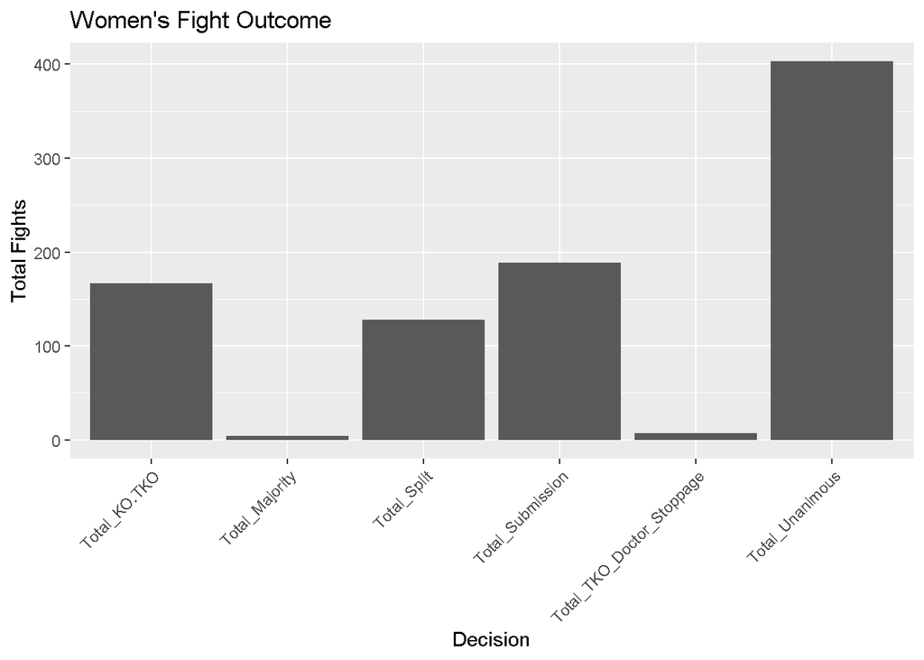

```r
# Creates a data frame with the total number of fights and how they were decided for the Women's data then plots the findings.

F_type_of_win <- F_data %>%  summarise(Total_Majority = sum(B_win_by_Decision_Majority)+
                                      sum(R_win_by_Decision_Majority),
                                      Total_Split = sum(B_win_by_Decision_Split) +
                                      sum(R_win_by_Decision_Split),
                                      Total_Unanimous = sum(B_win_by_Decision_Unanimous) +
                                      sum(R_win_by_Decision_Unanimous), Total_KO.TKO = sum(B_win_by_KO.TKO) +
                                      sum(R_win_by_KO.TKO), Total_Submission = sum(B_win_by_Submission) +
                                      sum(R_win_by_Submission), Total_TKO_Doctor_Stoppage =
                                      sum(B_win_by_TKO_Doctor_Stoppage) + sum(R_win_by_TKO_Doctor_Stoppage)) %>%
                                      select(Total_Majority, Total_Split, Total_Unanimous, Total_KO.TKO,
                                      Total_Submission, Total_TKO_Doctor_Stoppage) %>%
                                      t() %>% data.frame(WTotal_Fights = .) %>% rownames_to_column()

ggplot(data = F_type_of_win) + geom_col(aes(x = rowname,y = WTotal_Fights)) +
  theme(axis.text.x = element_text(angle = 45,hjust = 1)) + ggtitle("Women's Fight Outcome") +
  xlab("Decision") + ylab("Total Fights")
```

## Longest Record

The cleaned data has input from 3355 fights. A quick question that comes to mind is that of senoirity. Who has the most recorded fights with the UFC? Both Jim Miller and Donald Cerrone have 31 fights. The data is looked at for each ‘corner’. Some fighters have fought from both corners while others have only fought in one or the other. Looking at each corner separately gives a more complete picture.

```r
# Arranges a previously made column for the most number of fights for the red and blue corners for men's data.

M_data %>% arrange(desc(R_Total_fights)) %>% select(R_fighter, R_Total_fights) %>% head(1) %>%
  knitr::kable(caption = "Red Corner's Longest Record")
```

Red Corner’s Longest Record

| R_fighter | R_Total_fights |
| --- | --- |
| Jim Miller | 31 |

```r
M_data %>% arrange(desc(B_Total_fights)) %>% select(B_fighter, B_Total_fights) %>% head(1) %>%
  knitr::kable(caption = "Blue Corner's Longest Record")
```

Blue Corner’s Longest Record

| B_fighter | B_Total_fights |
| --- | --- |
| Donald Cerrone | 31 |

The same information is found using the women’s dataset to show that Jessica Andrade holds the current record of most bouts at 14. This again makes sense as women did not fight in the UFC until 2012. That is 19 years after the UFC began.

```r
# Arranges a previously made column for the most number of fights for the red and blue corners for the women's data.

F_data %>% arrange(desc(R_Total_fights)) %>% select(R_fighter, R_Total_fights) %>% head(1) %>%
  knitr::kable(caption = "Red Corner's Longest Record")
```

Red Corner’s Longest Record

| R_fighter | R_Total_fights |
| --- | --- |
| Jessica Andrade | 13 |

```r
F_data %>% arrange(desc(B_Total_fights)) %>% select(B_fighter, B_Total_fights) %>% head(1) %>%
  knitr::kable(caption = "Blue Corner's Longst Record")
```

Blue Corner’s Longst Record

| B_fighter | B_Total_fights |
| --- | --- |
| Jessica Andrade | 14 |

## Winning Percentage

One of the first variables or columns that I created was R_win_pct and B_win_pct. As guessed, this returns the value of the percent of victorious fights. The below code and table show the fighters and their win percentage in descending order for the red and blue corners. Some fighters have a perfect record, even though it only portrays a single fight like that of Ian Heinisch and Darko Stosic. For comparison, the average winning percentage is 63% for men fighters.

```r
# Arranges a previously made column of win percent in descending order per corner for men's fights.

M_data %>% select(R_fighter, R_win_pct, R_wins, R_losses) %>%
  arrange(desc(R_win_pct)) %>% head(3) %>% knitr::kable(caption = "Highest Red Corner Winning Percentage")
```

Highest Red Corner Winning Percentage

| R_fighter | R_win_pct | R_wins | R_losses |
| --- | --- | --- | --- |
| Darko Stosic | 1 | 1 | 0 |
| Michael Trizano | 1 | 2 | 0 |
| Brad Katona | 1 | 2 | 0 |

```r
M_data %>% select(B_fighter, B_win_pct, B_wins, B_losses) %>%
  arrange(desc(B_win_pct)) %>% head(3) %>% knitr::kable(caption = "Highest Blue Corner Winning Percentage")
```

Highest Blue Corner Winning Percentage

| B_fighter | B_win_pct | B_wins | B_losses |
| --- | --- | --- | --- |
| Petr Yan | 1 | 4 | 0 |
| Aleksandar Rakic | 1 | 3 | 0 |
| Ian Heinisch | 1 | 1 | 0 |

```r
M_data %>% mutate(R_avg_win_pct = mean(R_win_pct), B_avg_win_pct = mean(B_win_pct)) %>%
  select(R_avg_win_pct, B_avg_win_pct) %>% summarise(avg_win_pct = mean(R_avg_win_pct + B_avg_win_pct)/2) %>% knitr::kable(caption = "Average Winning Percentage")
```

Average Winning Percentage

| avg_win_pct |
| --- |
| 0.6257418 |

According to the women’s data, the average winning percentage of victorious fights is 60%. Again, the fighters are listed in descending order according to their win percentage. The best fighters are not necessarily listed first though because a perfect record can be achieved by a single fight.

```r
# Arranges a previously made column of win percent in descending order per corner for women's fights.

F_data %>% select(R_fighter, R_win_pct, R_wins, R_losses) %>%
  arrange(desc(R_win_pct)) %>% head(3) %>% knitr::kable(caption = "Highest Red Corner Winning Percentage")
```

Highest Red Corner Winning Percentage

| R_fighter | R_win_pct | R_wins | R_losses |
| --- | --- | --- | --- |
| Tatiana Suarez | 1 | 4 | 0 |
| Yan Xiaonan | 1 | 3 | 0 |
| Aspen Ladd | 1 | 2 | 0 |

```r
F_data %>% select(B_fighter, B_win_pct, B_wins, B_losses) %>%
  arrange(desc(B_win_pct)) %>% head(3) %>% knitr::kable(caption =  "Highest Blue Corner Winning Percentage")
```

Highest Blue Corner Winning Percentage

| B_fighter | B_win_pct | B_wins | B_losses |
| --- | --- | --- | --- |
| Sijara Eubanks | 1 | 2 | 0 |
| Antonina Shevchenko | 1 | 1 | 0 |
| Macy Chiasson | 1 | 1 | 0 |

```r
F_data %>% mutate(R_avg_win_pct = mean(R_win_pct), B_avg_win_pct = mean(B_win_pct)) %>%
  select(R_avg_win_pct, B_avg_win_pct) %>% summarise(avg_win_pct = mean(R_avg_win_pct + B_avg_win_pct)/2) %>%
  knitr::kable(caption = "Average Winning Percentage")
```

Average Winning Percentage

| avg_win_pct |
| --- |
| 0.5956509 |

# Red vs Blue Corner

When finding the average winning percentage for the fighters, a contrast was illuminated. The average red corner fighter in the men’s data is ~65% while the blue corner average win percent is roughly 5% less. Looking further into the difference between the red and blue corners reveals a bigger contrast.

```r
# Creates variables using Men's data that give total number of wins for each corner then creates data frame with the percentage of wins and color of corner.

B_corner_wins <- M_data %>% filter(Winner == "Blue") %>% count()
R_corner_wins <- M_data %>% filter(Winner == "Red") %>% count()
Total_wins <- R_corner_wins + B_corner_wins

plotting_df <- data.frame(win_pct = c(as.double(R_corner_wins/Total_wins),as.double(B_corner_wins/Total_wins)), corner = c("Red","Blue"))
```

```r
t.test(x = M_data$B_wins, y = M_data$R_wins, mu = 0, "two.sided")
```

```
##
##  Welch Two Sample t-test
##
## data:  M_data$B_wins and M_data$R_wins
## t = -12.812, df = 6221.3, p-value < 2.2e-16
## alternative hypothesis: true difference in means is not equal to 0
## 95 percent confidence interval:
##  -1.371116 -1.007211
## sample estimates:
## mean of x mean of y
##  3.643853  4.833016
```

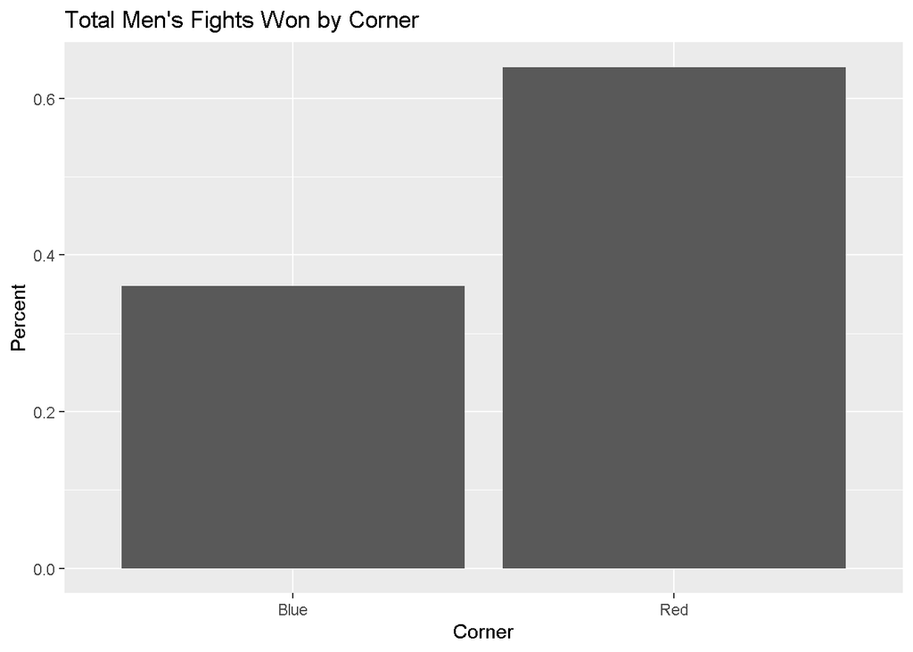

```r
# Creates a graph of the above data.

ggplot(data = plotting_df) + geom_col(aes(x = corner, y = win_pct)) + ggtitle("Total Men's Fights Won by Corner") +
  xlab("Corner") + ylab("Percent")
```

The red corner wins ~64% of all the fights leaving the blue corner with a 36% rate of winning for the men’s fights. The women’s data portrays a similar advantage to the red corner at ~58% and 42% for the blue corner. However, the red corner is not “lucky” as the numbers might suggest. The corner is not randomly chosen. Typically, the fighter defending a title, or more renowned and veteran is placed in the red corner. The challenger takes the blue corner. Even knowing the more experienced fighter is placed in the red corner, the nearly double winning rate is interesting.

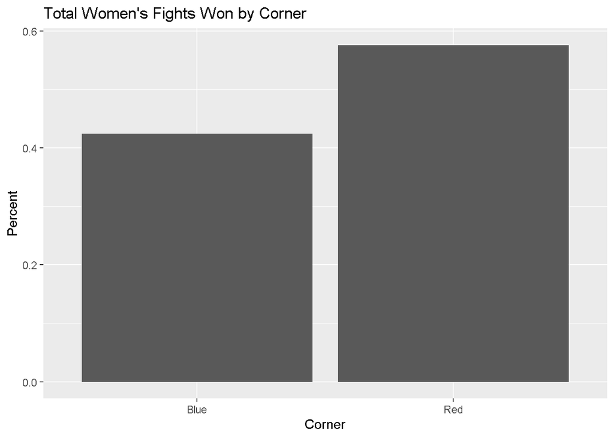

```r
# Creates variables using Woen's data that give total number of wins for each corner then creates data frame with the percentage of wins and color of corner. Lastly, a graph is generated to reflect the data.

WB_corner_wins <- F_data %>% filter(Winner == "Blue") %>% count()
WR_corner_wins <- F_data %>% filter(Winner == "Red") %>% count()
WTotal_wins <- WR_corner_wins + WB_corner_wins

Wplotting_df <- data.frame(win_pct = c(as.double(WR_corner_wins/WTotal_wins),as.double(WB_corner_wins/WTotal_wins)), corner = c("Red","Blue"))

ggplot(data = Wplotting_df) + geom_col(aes(x = corner, y = win_pct)) +
  ggtitle("Total Women's Fights Won by Corner") + xlab("Corner") + ylab("Percent")
```

## Referee

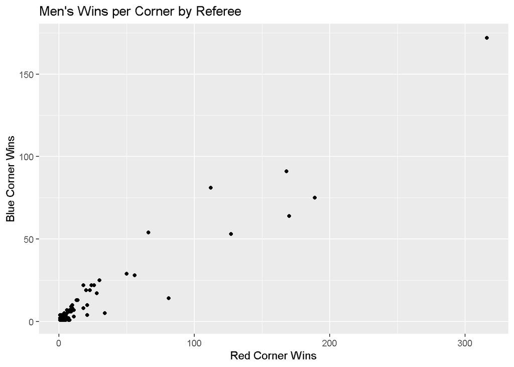

```r
# Creates variables to find the percentage of wins per corner from the men's data then joins with another data frame that groups by the referee during each fight. A graph is then generated to show the percentage of red vs blue corner wins for each referee.

B_corner_wins2 <- M_data %>% filter(Winner == "Blue") %>% group_by(Referee) %>%  count()
R_corner_wins2 <- M_data %>% filter(Winner == "Red") %>%  group_by(Referee) %>% count()
Total_wins2 <- R_corner_wins + B_corner_wins

plotting_df <- data.frame(win_pct = c(as.double(R_corner_wins/Total_wins),as.double(B_corner_wins/Total_wins)), corner = c("Red","Blue"))

wins <- R_corner_wins2 %>% inner_join(B_corner_wins2, by = "Referee")
ggplot(data = wins) + geom_point(aes(x = n.x, y = n.y)) + ggtitle("Men's Wins per Corner by Referee") +
  xlab("Red Corner Wins") + ylab("Blue Corner Wins")
```

The women’s plot shows a different picture. First, you must consider the sample size. The men’s data has more data input showing a more condensed plot. The women’s plot is much more scattered, partly because of the decreased sample size. The referee represented by the point on the top right corner shows the expected trend of 2 to 1 in favor of red. The point just below that shows a referee with a 15 to 4 rate in favor of red. On the other end of the spectrum, there is a referee that has a 4 to 1 record of blue corner wins.

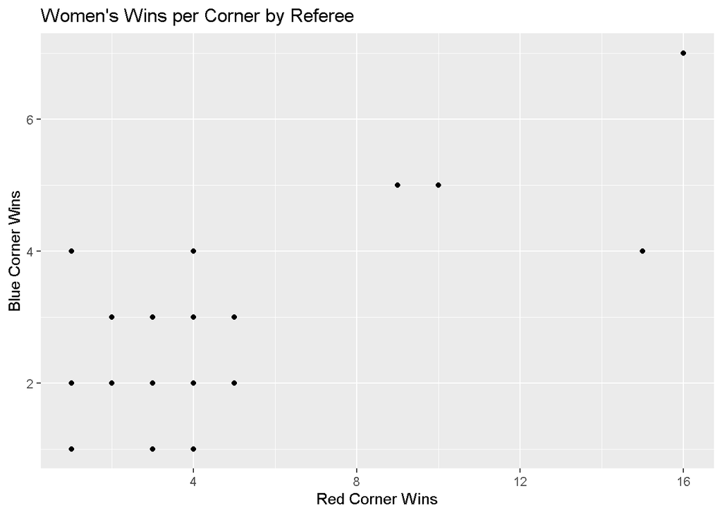

```r
# Creates variables to find the percentage of wins per corner from the women's data then joins with another data frame that groups by the referee during each fight. A graph is then generated to show the percentage of red vs blue corner wins for each referee.

WB_corner_wins2 <- F_data %>% filter(Winner == "Blue") %>% group_by(Referee) %>%  count()
WR_corner_wins2 <- F_data %>% filter(Winner == "Red") %>% group_by(Referee) %>%  count()
WTotal_wins2 <- WR_corner_wins + WB_corner_wins

Wplotting_df <- data.frame(win_pct = c(as.double(WR_corner_wins/WTotal_wins),as.double(WB_corner_wins/WTotal_wins)), corner = c("Red","Blue"))



w_wins <- WR_corner_wins2 %>% inner_join(WB_corner_wins2, by = "Referee")
ggplot(data = w_wins) + geom_point(aes(x = n.x, y = n.y)) + ggtitle("Women's Wins per Corner by Referee") +
  xlab("Red Corner Wins") + ylab("Blue Corner Wins")
```

## Location

In keeping with the same thought as above, let’s look to see if the arena has any impact on the red vs blue corner trend. In the men’s data there is no significant information. The location with the, by far, most fights has the typical 2 to 1 red corner ratio with all the other locations clustered closely around that mark.

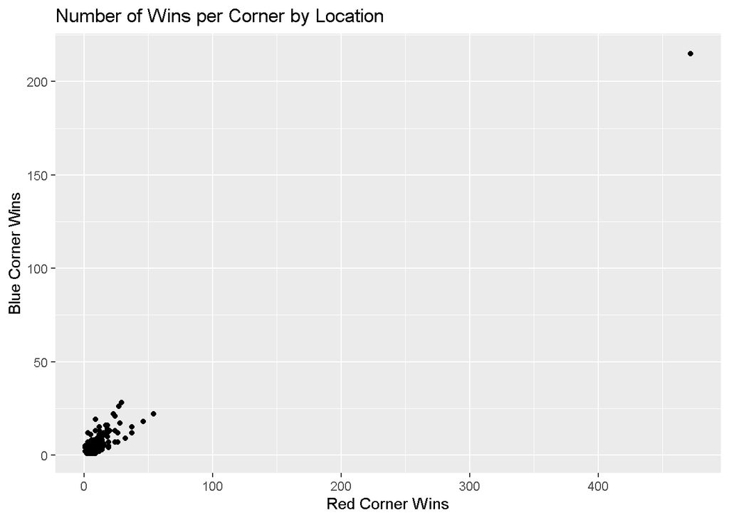

```r
# Creates variables to find the percentage of wins per corner from the men's data then joins with another data frame that groups by the location of each fight. A graph is then generated to show the percentage of red vs blue corner wins for each referee.

B_corner_wins3 <- M_data %>% filter(Winner == "Blue") %>% group_by(location) %>%  count()
R_corner_wins3 <- M_data %>% filter(Winner == "Red") %>%  group_by(location) %>% count()
Total_wins3 <- R_corner_wins + B_corner_wins

plotting_df <- data.frame(win_pct = c(as.double(R_corner_wins/Total_wins),as.double(B_corner_wins/Total_wins)), corner = c("Red","Blue"))

wins2 <- R_corner_wins3 %>% inner_join(B_corner_wins3, by = "location")
ggplot(data = wins2) + geom_point(aes(x = n.x, y = n.y)) + ggtitle("Number of Wins per Corner by Location") +
  xlab("Red Corner Wins") + ylab("Blue Corner Wins")
```

As for the women’s data, the same anomaly applies. Due to the decrease sample size one can see a deviation from the trend more easily. On the left you see a 4 to 1 blue corner advantage location and a 6 to 1 in favor of the red corner towards the right side of the plot.

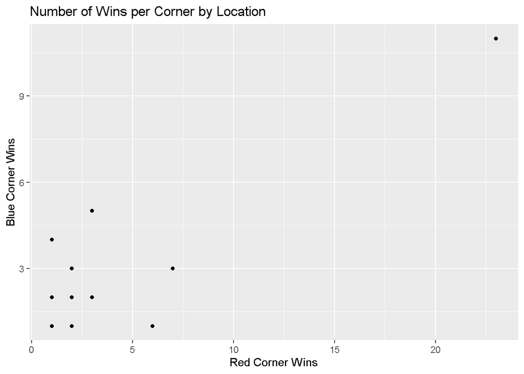

```r
# Creates variables to find the percentage of wins per corner from the women's data then joins with another data frame that groups by the location of each fight. A graph is then generated to show the percentage of red vs blue corner wins for each referee.

WB_corner_wins3 <- F_data %>% filter(Winner == "Blue") %>% group_by(location) %>%  count()
WR_corner_wins3 <- F_data %>% filter(Winner == "Red") %>%  group_by(location) %>% count()
WTotal_wins3 <- WR_corner_wins + WB_corner_wins

Wplotting_df <- data.frame(win_pct = c(as.double(WR_corner_wins/WTotal_wins),as.double(WB_corner_wins/WTotal_wins)), corner = c("Red","Blue"))

w_wins2 <- WR_corner_wins3 %>% inner_join(WB_corner_wins3, by = "location")
ggplot(data = w_wins2) + geom_point(aes(x = n.x, y = n.y)) + ggtitle("Number of Wins per Corner by Location") +
  xlab("Red Corner Wins") + ylab("Blue Corner Wins")
```

### Average Fight Length

```r
# Finds the average length of a Men's fight.

M_data %>% summarise(avg_no_of_rounds = mean(no_of_rounds)) %>%
  knitr::kable(caption = "Average Length of Men's Fight")
```

Average Length of Men’s Fight

| avg_no_of_rounds |
| --- |
| 3.224018 |

```r
# Finds the average length of a Women's fight.

F_data %>% summarise(avg_no_of_rounds = mean(no_of_rounds)) %>%
  knitr::kable(caption = "Average Length of Women's Fight")
```

Average Length of Women’s Fight

| avg_no_of_rounds |
| --- |
| 3.301508 |

### Total rounds fought

```r
# Returns the mean of the total number of rounds fought for Men.

M_data %>% summarise(avg_time_fighting = mean(R_total_rounds_fought + B_total_rounds_fought)) %>%
  knitr::kable(caption = "Average Total Rounds Fought")
```

Average Total Rounds Fought

| avg_time_fighting |
| --- |
| 30.25982 |

```r
# Returns the mean of the total number of rounds fought for Women.

F_data %>% summarise(avg_time_fighting = mean(R_total_rounds_fought+B_total_rounds_fought)) %>%
  knitr::kable(caption = "Average Total Rounds Fought")
```

Average Total Rounds Fought

| avg_time_fighting |
| --- |
| 19.11558 |

## Age

Next, we look to see if the fighter’s age has any effect on their success. Starting with the men’s data, we find that Randy Couture is the oldest fighter. Sage Northcutt takes the position of the youngest fighter. Let’s look at each of their win percentage and compare it with the average fighter. The oldest fighter, Couture, has a win percent of 76%. Northcutt, the youngest, has a win percent of 77%. Both fighters have a higher than average win percent which is 63%. There is only a 1% difference between the oldest and youngest fighters, but Couture has more than double the number of fights under his belt.

```r
# Returns three data frames based on the men's data:                                                               1) the first is the win percentage of the oldest fighter                                                            2) the second is the win percentage of the youngest fighter                                                        3) the last is the mean win percentage of all fighters

age1 <- M_data %>% select(B_age, B_fighter) %>% arrange(B_age)
age2 <- M_data %>% select(B_age, B_fighter) %>% arrange(desc(B_age))
age3 <- M_data %>% select(R_age, R_fighter) %>% arrange(R_age)
age4 <- M_data %>% select(R_age, R_fighter) %>% arrange(desc(R_age))

R_oldest_win_pct <- M_data %>% filter(R_fighter == "Randy Couture") %>% summarise(win_pct = sum(R_win_pct))

B_oldest_win_pct <- M_data %>% filter(B_fighter == "Randy Couture") %>% summarise(win_pct = sum(B_win_pct))

(oldest <- (R_oldest_win_pct + B_oldest_win_pct)/15) %>%
  knitr::kable(caption = "Oldest Fighter's Winning Percentage")
```

Oldest Fighter’s Winning Percentage

| win_pct |
| --- |
| 0.7640438 |

```r
(youngest <- M_data %>% filter(R_fighter == "Sage Northcutt") %>% summarise(win_pct = sum(R_win_pct)/7)) %>% knitr::kable(caption = "Youngets Fighter's Winning Percentage")
```

Youngets Fighter’s Winning Percentage

| win_pct |
| --- |
| 0.7710884 |

```r
(avg <- M_data %>% mutate(avg_win_pct = (R_win_pct + B_win_pct)/2) %>% summarise(avg_win_pct = mean(avg_win_pct))) %>% knitr::kable(caption = "Average Fighter's Winning Percentage")
```

Average Fighter’s Winning Percentage

| avg_win_pct |
| --- |
| 0.6257418 |

I created a visual using the smooth aesthetic to show the fighter’s age in the y-axis and the win percentage on the x-axis. There are two graphs, one for each corner. For easier recognition, the red corner is colored red, and the blue graph shows the data from the blue corner. Both visuals have a green line showing the average fighter’s win percent for that corner. The similarity between the corners is interesting to see. The shape of the graph is nearly the same. Both graphs show that the younger fighters do really well or very poorly at winning fights. The older fighters are more clustered around the middle of the plot on either side of the green average win percentage line.

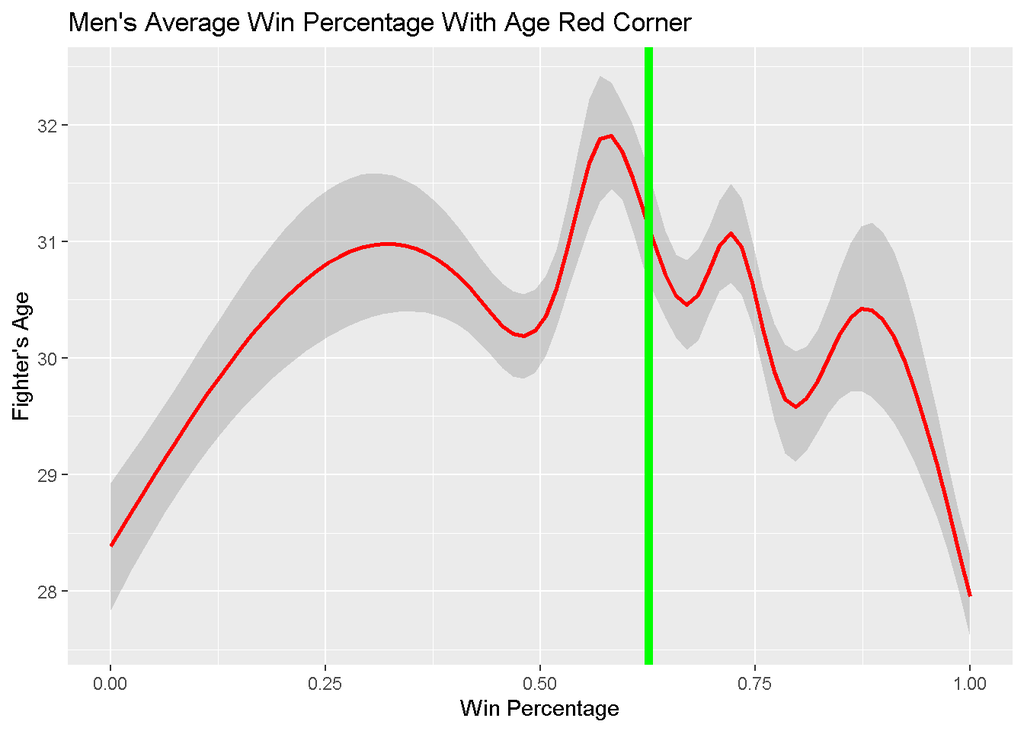

```r
MR_age_plot <- M_data %>% select(R_fighter, R_win_pct, R_age)
MB_age_plot <- M_data %>% select(B_fighter, B_win_pct, B_age)

ggplot(MR_age_plot) + geom_smooth(aes(x = R_win_pct, y = R_age), color = "red") +
  geom_vline(xintercept = 0.6257418, color = "green", size = 2) +
  ggtitle("Men's Average Win Percentage With Age Red Corner") +
  xlab("Win Percentage") + ylab("Fighter's Age")
```

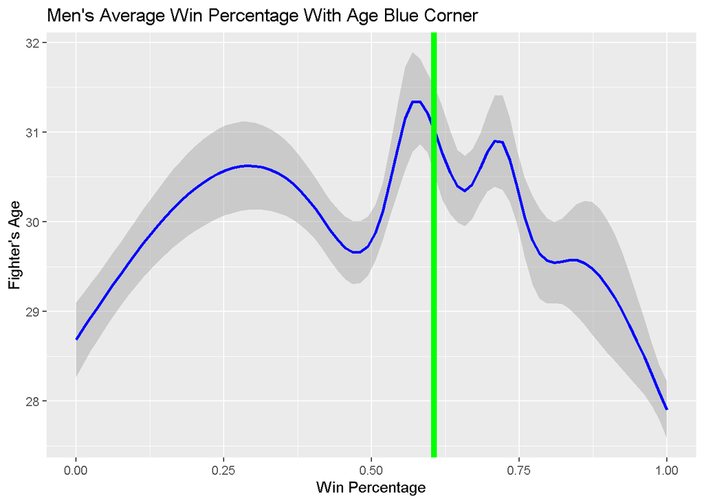

```r
ggplot(MB_age_plot) + geom_smooth(aes(x = B_win_pct, y = B_age), color = "blue") +
  geom_vline(xintercept = 0.6054667, color = "green", size = 2) +
  ggtitle("Men's Average Win Percentage With Age Blue Corner") +
  xlab("Win Percentage") + ylab("Fighter's Age")
```

The oldest and youngest women fighters are Marion Reneau and Maycee Barber respectively. Barber boasts a 100% winning percent but has only had a single fight. Reneau holds a 69% winning record. Both of which are above the 60% average.

```r
# Returns three data frames based on the women's data:                                                              1) the first is the win percentage of the oldest fighter                                                            2) the second is the win percentage of the youngest fighter                                                         3) the last is the mean win percentage of all fighters

age21 <- F_data %>% select(B_age, B_fighter) %>% arrange(B_age)
age22 <- F_data %>% select(B_age, B_fighter) %>% arrange(desc(B_age))
age23 <- F_data %>% select(R_age, R_fighter) %>% arrange(R_age)
age24 <- F_data %>% select(R_age, R_fighter) %>% arrange(desc(R_age))

WR_oldest_win_pct <- F_data %>% filter(R_fighter == "Marion Reneau") %>% summarise(win_pct = sum(R_win_pct))

WB_oldest_win_pct <- F_data %>% filter(B_fighter == "Marion Reneau") %>% summarise(win_pct = sum(B_win_pct))

(W_oldest_win_pct <- (WR_oldest_win_pct + WB_oldest_win_pct)/8) %>%
  knitr::kable(caption = "Oldest Fighter's Winning Percentage")
```

Oldest Fighter’s Winning Percentage

| win_pct |
| --- |
| 0.6898313 |

```r
WR_youngest_win_pct <- F_data %>% filter(R_fighter == "Maycee Barber") %>% summarise(win_pct = sum(R_win_pct))

(W_youngest_win_pct <-(WR_youngest_win_pct/1)) %>%
  knitr::kable(caption = "Youngest Fighter's Winning Percentage")
```

Youngest Fighter’s Winning Percentage

| win_pct |
| --- |
| 1 |

```r
(avg_win_pct <- F_data  %>% mutate(avg_win_pct = (R_win_pct + B_win_pct)/2) %>%
    summarise(avg_win_pct = mean(avg_win_pct))) %>%
  knitr::kable(caption = "Average Fighter's Winning Percentage")
```

Average Fighter’s Winning Percentage

| avg_win_pct |
| --- |
| 0.5956509 |

The women’s data has yet to fail to intrigue me. The blue corner smooth graph of the fighter age and win percentage is similar to the men’s graphs. Overall it has a parabola shape with the younger fighters having a really good or really bad record and the older fighters hover around the average win percentage mark. The women’s red corner tells a different story. This graph is almost skewed and shows that the fighters with below average win percent are also the ones that are more advanced in age while the younger fighters clearly have a higher than average winning record.

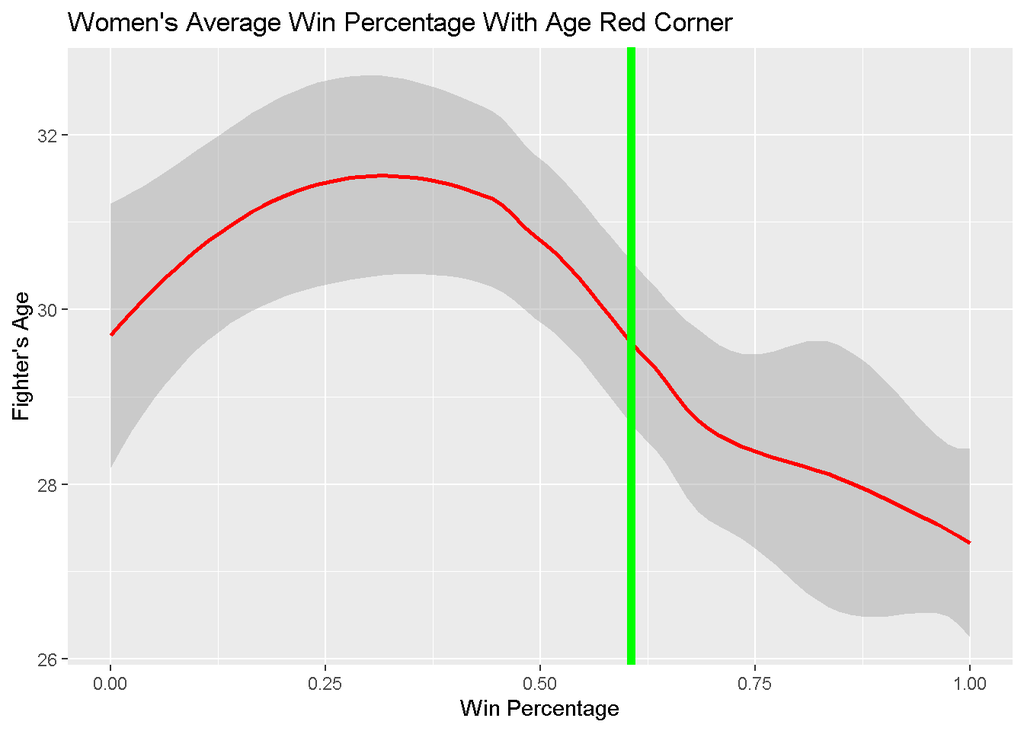

```r
WR_age_plot <- F_data %>% select(R_fighter, R_win_pct, R_age)
WB_age_plot <- F_data %>% select(B_fighter, B_win_pct, B_age)

ggplot(WR_age_plot) + geom_smooth(aes(x = R_win_pct, y = R_age), color = "red") +
  geom_vline(xintercept = 0.6062128, color = "green", size = 2) +
  ggtitle("Women's Average Win Percentage With Age Red Corner") +
  xlab("Win Percentage") + ylab("Fighter's Age")
```

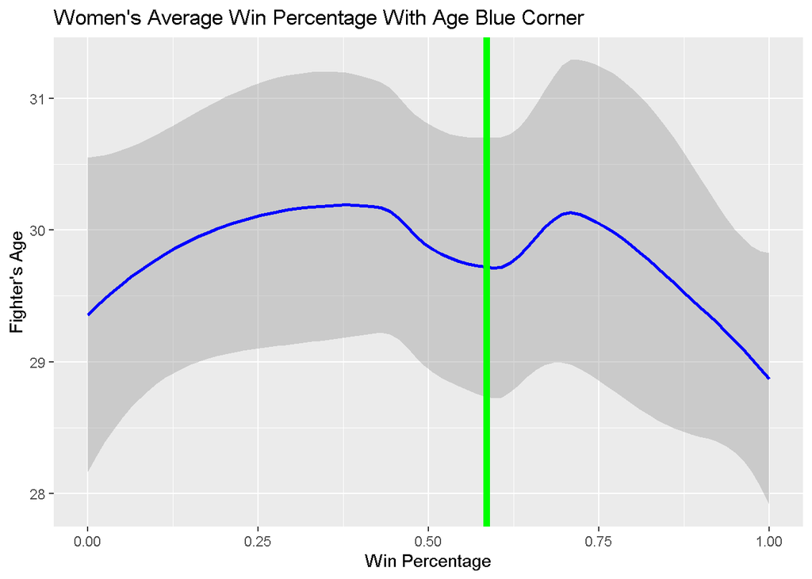

```r
ggplot(WB_age_plot) + geom_smooth(aes(x = B_win_pct, y = B_age), color = "blue") +
  geom_vline(xintercept = 0.585089, color = "green", size = 2) +
  ggtitle("Women's Average Win Percentage With Age Blue Corner") +
  xlab("Win Percentage") + ylab("Fighter's Age")
```

## Fighting Stance

Another variable I wanted to consider was that of fight stance. The below graph is titled ‘Most Winning Fighting Stance’ while it could have just as easily been titled most common fighting stance. The graphs are colored to show the corner they represent. There seems to be more input into the red corner graph as the y-axis is increased. The shape of the graphs appears identical.

```r
# Returns the fighting stance with the most wins from the men's data then graphs the results in a histogram.

M_data %>% select(R_Stance, R_wins, R_losses) %>% group_by(R_Stance) %>% summarise(Total_wins = sum(R_wins)) %>%
  knitr::kable(caption = "Red Corner's Total Wins by Fighting Stance")
```

Red Corner’s Total Wins by Fighting Stance

| R_Stance | Total_wins |
| --- | --- |
|  | 86 |
| Open Stance | 44 |
| Orthodox | 10928 |
| Southpaw | 3880 |
| Switch | 315 |

```r
M_data %>% select(B_Stance, B_wins, B_losses) %>% group_by(B_Stance) %>% summarise(Total_wins = sum(B_wins)) %>%
  knitr::kable(caption = "Blue Corner's Total Wins by Fighting Stance")
```

Blue Corner’s Total Wins by Fighting Stance

| B_Stance | Total_wins |
| --- | --- |
|  | 85 |
| Open Stance | 16 |
| Orthodox | 8250 |
| Southpaw | 2826 |
| Switch | 323 |

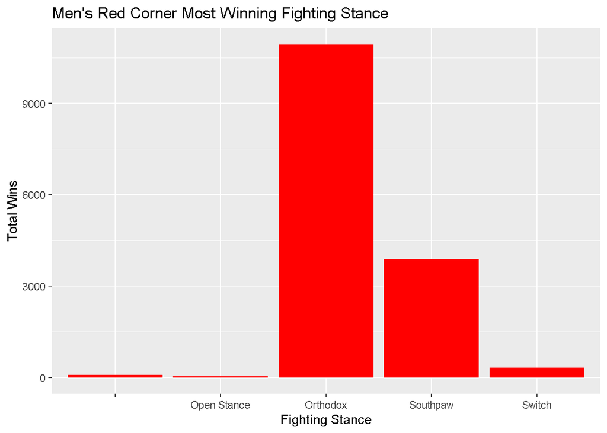

```r
MR_stance <- M_data %>% select(R_Stance, R_wins)
MB_stance <- M_data %>% select(B_Stance, B_wins)

ggplot(MR_stance, aes(x = R_Stance, y = R_wins)) + geom_col(fill = "red") +
  ggtitle("Men's Red Corner Most Winning Fighting Stance") + xlab("Fighting Stance") +
  ylab("Total Wins")
```

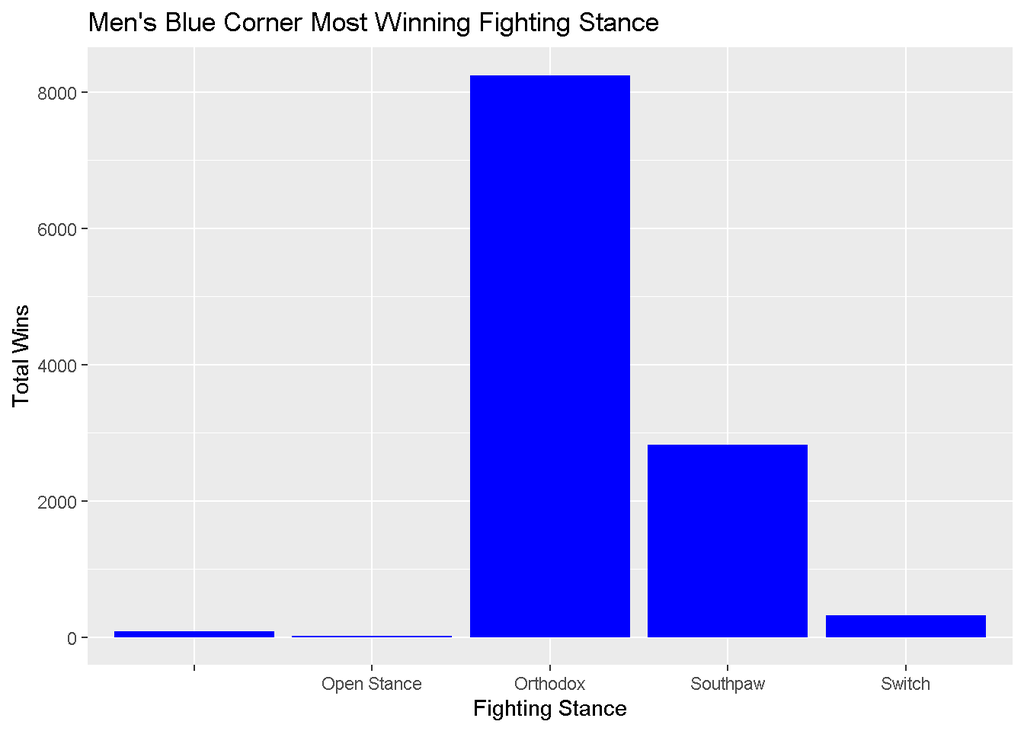

```r
ggplot(MB_stance, aes(x = B_Stance, y = B_wins)) + geom_col(fill = "blue") +
  ggtitle("Men's Blue Corner Most Winning Fighting Stance") + xlab("Fighting Stance") +
  ylab("Total Wins")
```

The women’s data shows the same favorite fighting stance of Orthodox. A small difference is the higher occurence of the unnamed fighting stance for both the red and blue corners.

```r
# Returns the fighting stance with the most wins from the women's data then graphs the results in a histogram.

F_data %>% select(R_Stance, R_wins, R_losses) %>% group_by(R_Stance) %>% summarise(Total_wins = sum(R_wins)) %>%
  knitr::kable(caption = "Red Corner's Total Wins by Fighting Stance")
```

Red Corner’s Total Wins by Fighting Stance

| R_Stance | Total_wins |
| --- | --- |
|  | 31 |
| Orthodox | 427 |
| Southpaw | 36 |
| Switch | 2 |

```r
F_data %>% select(B_Stance, B_wins, B_losses) %>% group_by(B_Stance) %>% summarise(Total_wins = sum(B_wins)) %>%
  knitr::kable(caption = "Blue Corner's Total Wins by Fighting Stance")
```

Blue Corner’s Total Wins by Fighting Stance

| B_Stance | Total_wins |
| --- | --- |
|  | 33 |
| Orthodox | 342 |
| Southpaw | 23 |
| Switch | 4 |

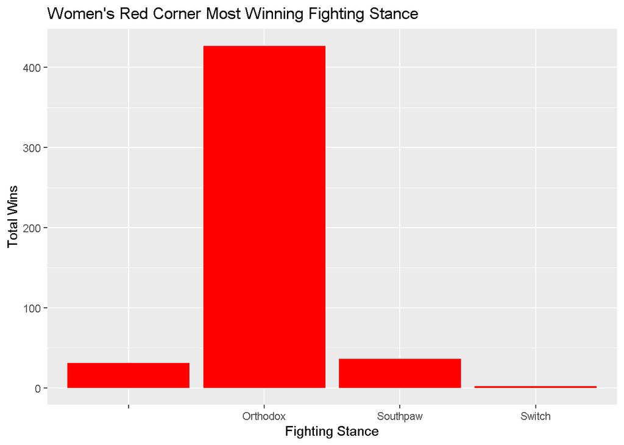

```r
WR_stance <- F_data %>% select(R_Stance, R_wins)
WB_stance <- F_data %>% select(B_Stance, B_wins)

ggplot(WR_stance, aes(x = R_Stance, y = R_wins)) + geom_col(fill = "red") +
  ggtitle("Women's Red Corner Most Winning Fighting Stance") + xlab("Fighting Stance") +
  ylab("Total Wins")
```

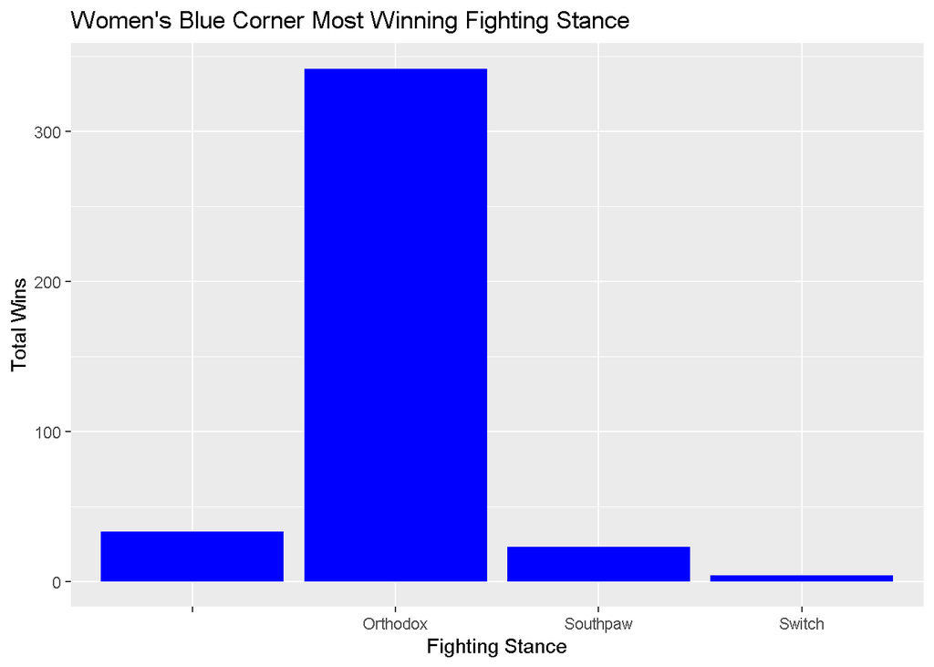

```r
ggplot(WB_stance, aes(x = B_Stance, y = B_wins)) + geom_col(fill = "blue") +
  ggtitle("Women's Blue Corner Most Winning Fighting Stance") + xlab("Fighting Stance") +
  ylab("Total Wins")
```

## Fighter’s Reach and Height

A fighter’s reach, or arm length, is a significant variable. I created a column that gives each fighter’s reach to height ratio. A boxplot visual clearly displays the average reach to height ratio per weight class. The graphs are again colored to indicate the corner and the green line marks the average fighter’s reach to height figure. In the red corner, the bantamweight fighters have a below average reach to height ratio but there is an outlier with a significant reach advantage. Catch, featherweight and flyweight all have a close to average reach. The light heavyweight and welterweight classes have outliers on both ends of the spectrum while the lightweight, middleweight and heavyweight all have outliers with above average reach to height ratios. The blue corner demonstrates a similar pattern with the average ratio of all weight classes falling closely in line with the average reach for all fighters. Reach advantage outliers can be found in light heavyweight, lightweight and middleweight and welterweight. Disadvantageous outliers are seen in catchweight, lightweight and welterweight classes.

```r
# Arranges a previously made column in men's data, RH, for reach/height for each fighter and plots the average reachto height ratio per weight class. Lastly, the red line is added to show the overall average reach to height ratio.

M_data %>% select(R_fighter, B_fighter, R_win_pct, B_win_pct, R_RH, B_RH) %>% head(3) %>%
  knitr::kable(caption = "Fighter's Winning Percentage and Reach to Height Ratio")
```

Fighter’s Winning Percentage and Reach to Height Ratio

| R_fighter | B_fighter | R_win_pct | B_win_pct | R_RH | B_RH |
| --- | --- | --- | --- | --- | --- |
| Henry Cejudo | Marlon Moraes | 0.8000000 | 0.8000000 | 1.000000 | 1.015151 |
| Tony Ferguson | Donald Cerrone | 0.9333333 | 0.7419355 | 1.070423 | 1.000000 |
| Jimmie Rivera | Petr Yan | 0.7500000 | 1.0000000 | 1.062500 | 1.000000 |

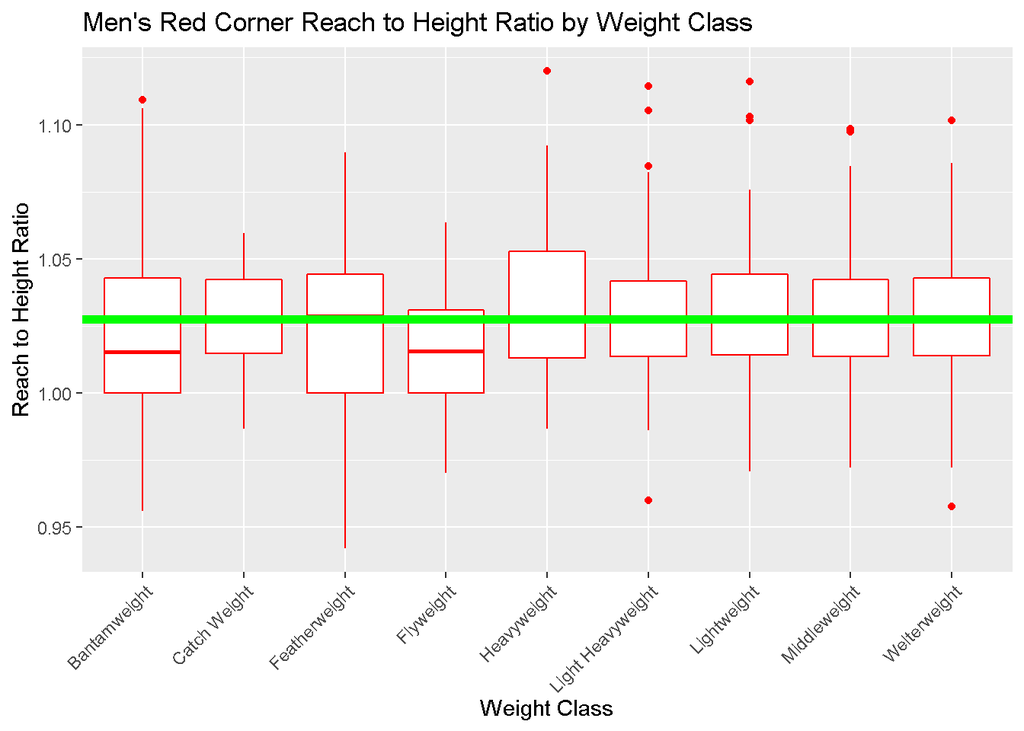

```r
ggplot(M_data, aes(x = weight_class, y = R_RH)) + geom_boxplot(color = "red") +
  theme(axis.text.x=element_text(angle=45,hjust=1)) +
  ggtitle("Men's Red Corner Reach to Height Ratio by Weight Class") +
  xlab("Weight Class") + ylab("Reach to Height Ratio") +
  geom_hline(yintercept = 1.027458, color = "green", size =2)
```

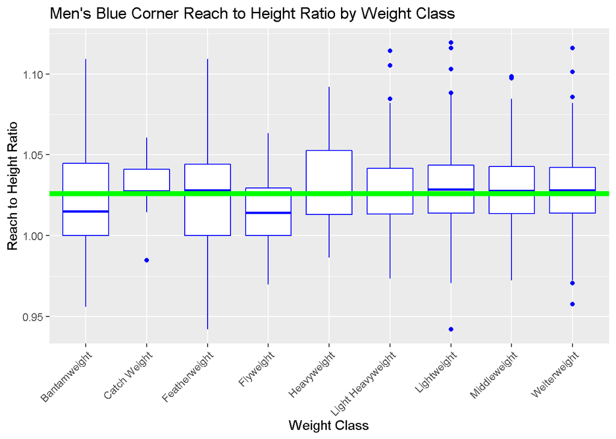

```r
ggplot(M_data, aes(x = weight_class, y = B_RH)) + geom_boxplot(color = "blue") +
  theme(axis.text.x=element_text(angle=45,hjust=1)) +
  ggtitle("Men's Blue Corner Reach to Height Ratio by Weight Class") +
  xlab("Weight Class") + ylab("Reach to Height Ratio") +
  geom_hline(yintercept = 1.026083, color = "green", size =2)
```

The women’s data continues with the trend of showing sharper contrast due to the smaller sample size. In the red corner, all weight classes have an above average reach to height ratio except for the women’s strawweight. The strawweight does have a favorable outlier but also holds some of the most disadvantaged fighters. The women’s bantamweight class also catches your eye with a couple outliers on both sides of the average line. The women’s blue corner is a bit different. Women’s flyweight and bantamweight both have below average reach while featherweight and strawweight have above average numbers. The women’s flyweight and strawweight boast outliers with significant reach to height ratios.

```r
# Arranges a previously made column in women's data, RH, for reach/height for each fighter and plots the average reachto height ratio per weight class. Lastly, the red line is added to show the overall average reach to height ratio.

F_data %>% select(R_fighter, B_fighter, R_win_pct, B_win_pct, R_RH, B_RH) %>% head(3) %>%
  knitr::kable(caption = "Fighter's Winning Percentage and Reach to Height Ratio")
```

Fighter’s Winning Percentage and Reach to Height Ratio

| R_fighter | B_fighter | R_win_pct | B_win_pct | R_RH | B_RH |
| --- | --- | --- | --- | --- | --- |
| Valentina Shevchenko | Jessica Eye | 0.7142857 | 0.4000000 | 1.015385 | 1.0000000 |
| Tatiana Suarez | Nina Ansaroff | 1.0000000 | 0.6666667 | 1.015385 | 0.9846154 |
| Karolina Kowalkiewicz | Alexa Grasso | 0.5555556 | 0.5000000 | 1.015873 | 1.0153846 |

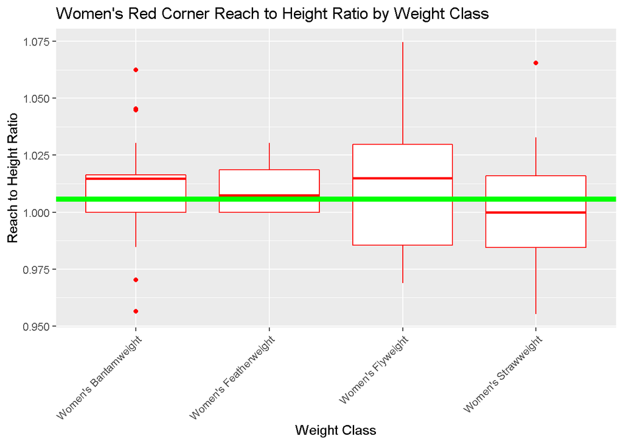

```r
ggplot(F_data, aes(x = weight_class, y = R_RH)) + geom_boxplot(color = "red") +
  theme(axis.text.x=element_text(angle=45,hjust=1)) +
  ggtitle("Women's Red Corner Reach to Height Ratio by Weight Class") +
  xlab("Weight Class") + ylab("Reach to Height Ratio") +
  geom_hline(yintercept = 1.005845, color = "green", size = 2)
```

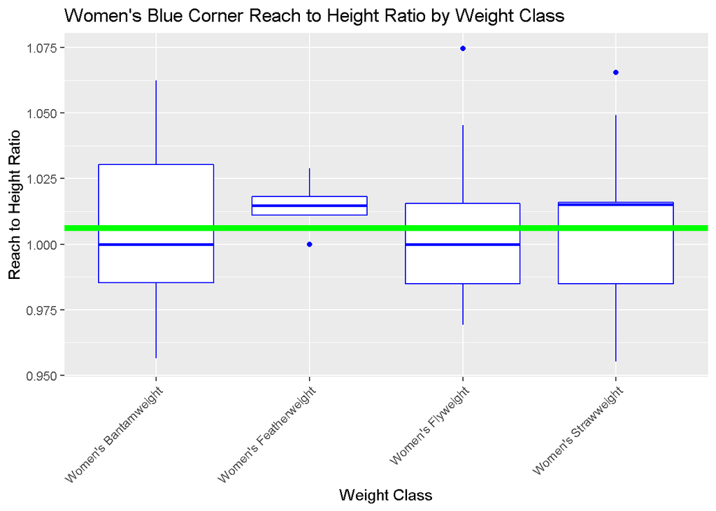

```r
ggplot(F_data, aes(x = weight_class, y = B_RH)) + geom_boxplot(color = "blue") +
  theme(axis.text.x=element_text(angle=45,hjust=1)) +
  ggtitle("Women's Blue Corner Reach to Height Ratio by Weight Class") +
  xlab("Weight Class") + ylab("Reach to Height Ratio") +
  geom_hline(yintercept = 1.006242, color = "green", size = 2)
```

## Accuracy

The last variable that I created was a fighter’s strike percent. This figure shows the percentage of strikes landed from the total strikes attempted. It can be used to measure a fighter’s accuracy. The original data had the number of attempts and landed strikes for each type of strike. I used the total attempt and total landed variables to create the strike percent column. Below is a table that shows the fighter with the highest accuracy, strike percent, for each weight class.

```r
# From the men's data, two data frames are created reflecting the maximum percentage of strikes landed by corner.

M_data  %>% group_by(weight_class) %>% filter(R_strike_pct == max(R_strike_pct)) %>%
  select(R_fighter, R_strike_pct, weight_class) %>%
  knitr::kable(caption = "Red Corner's Most Accurate by Weight Class")
```

Red Corner’s Most Accurate by Weight Class

| R_fighter | R_strike_pct | weight_class |
| --- | --- | --- |
| Johnny Walker | 0.9090909 | Light Heavyweight |
| Hakeem Dawodu | 1.0000000 | Featherweight |
| Brandon Moreno | 0.8750000 | Flyweight |
| Aaron Phillips | 0.7956204 | Bantamweight |
| Vitor Belfort | 0.6245059 | Catch Weight |
| Nate Diaz | 0.9333333 | Lightweight |
| Joe Doerksen | 0.9166667 | Middleweight |
| Randy Couture | 0.8965517 | Heavyweight |

```r
M_data  %>% group_by(weight_class) %>% filter(B_strike_pct == max(B_strike_pct)) %>%
  select(B_fighter, B_strike_pct, weight_class) %>%
  knitr::kable(caption = "Blue Corner's Most Accurate by Weight Class")
```

Blue Corner’s Most Accurate by Weight Class

| B_fighter | B_strike_pct | weight_class |
| --- | --- | --- |
| Fabio Maldonado | 0.6795699 | Catch Weight |
| Jack May | 0.9583333 | Heavyweight |
| Tatsuya Kawajiri | 0.9393939 | Featherweight |
| Justin Scoggins | 0.7966102 | Flyweight |
| Yoel Romero | 1.0000000 | Middleweight |
| Ryan Jimmo | 1.0000000 | Light Heavyweight |
| Issei Tamura | 0.8555556 | Bantamweight |
| Rousimar Palhares | 1.0000000 | Middleweight |

The below code makes a quick reference to the above fighters with highest accuracy per weight class and their corresponding winning percentage.

```r
# Creates a sub set reflecting the win percentage of the above fighters filtered to only the fights that include the above fighters.

M_data %>% filter(B_fighter %in% c("Rousimar Palhares", "Ryan Jimmo", "Yoel Romero",
                                   "Issei Tamura","Justin Scoggins", "Tatsuya Kawajiri",
                                   "Jack May", "Fabio Maldonado") |
                    R_fighter %in% c("Johnny Walker", "Hakeem Dawodu", "Brandon Moreno", "Aaron Phillips",
                                     "Victor Belfort", "Nate Diaz", "Joe Doerksen", "Randy couture")) %>%
  select(R_fighter, B_fighter, weight_class, R_win_pct, B_win_pct) %>% head(3) %>%
  knitr::kable(caption = "Highest Accuracy and Corresponding Winning Percentage")
```

Highest Accuracy and Corresponding Winning Percentage

| R_fighter | B_fighter | weight_class | R_win_pct | B_win_pct |
| --- | --- | --- | --- | --- |
| Johnny Walker | Justin Ledet | Light Heavyweight | 1.0 | 0.75 |
| Hakeem Dawodu | Kyle Bochniak | Featherweight | 0.5 | 0.40 |
| Hakeem Dawodu | Austin Arnett | Featherweight | 0.0 | 0.00 |

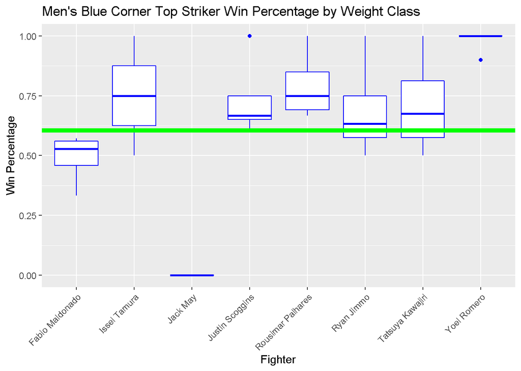

```r
# Creates two boxplots reflecting men's data for red and blue corners. The fighters with the best strikes landed percentage are shown on the x-axis and their corresponding win percentage is on the y-axis. The green line shows the average win percentage for all fighters.

MB_strike_plot <- M_data %>% filter(B_fighter %in% c("Rousimar Palhares", "Ryan Jimmo", "Yoel Romero",
                                   "Issei Tamura","Justin Scoggins", "Tatsuya Kawajiri",
                                   "Jack May", "Fabio Maldonado")) %>% select(B_fighter, B_win_pct)

ggplot(MB_strike_plot) + geom_boxplot(aes(x = B_fighter, y = B_win_pct), color = "blue") +
  theme(axis.text.x=element_text(angle=45,hjust=1)) +
  ggtitle("Men's Blue Corner Top Striker Win Percentage by Weight Class") +
  xlab("Fighter") + ylab("Win Percentage") + geom_hline(yintercept = 0.6054667, color = "green", size = 2)
```

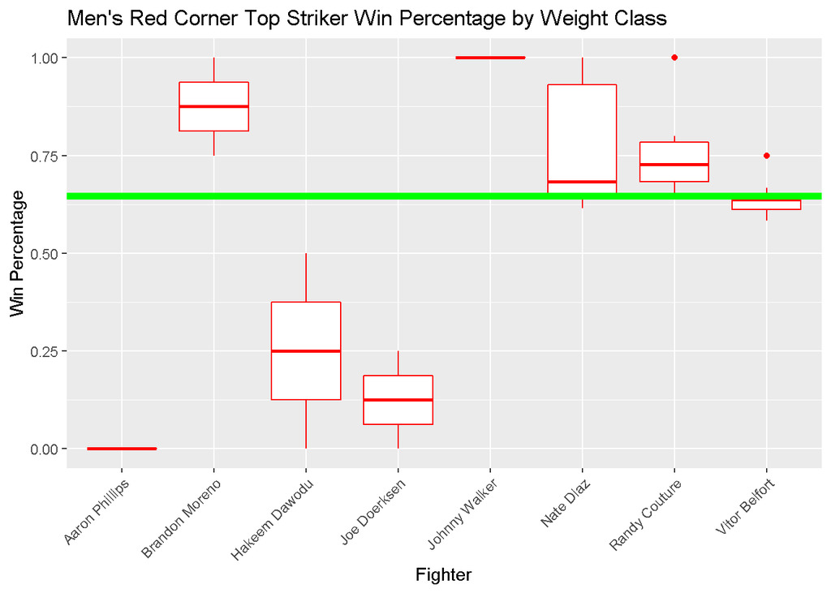

```r
MR_strike_plot <- M_data %>% filter(R_fighter %in% c("Johnny Walker", "Hakeem Dawodu", "Brandon Moreno",
                                    "Aaron Phillips","Vitor Belfort", "Nate Diaz", "Joe Doerksen",
                                    "Randy Couture")) %>% select(R_fighter, R_win_pct)

ggplot(MR_strike_plot) + geom_boxplot(aes(x = R_fighter, y = R_win_pct), color = "red") +
  theme(axis.text.x=element_text(angle=45,hjust=1)) +
  ggtitle("Men's Red Corner Top Striker Win Percentage by Weight Class") +
  xlab("Fighter") + ylab("Win Percentage") + geom_hline(yintercept = 0.6460169, color = "green", size = 2)
```

```r
# From the women's data, two data frames are created reflecting the maximum percentage of strikes landed by corner for each weight class.

F_data %>% group_by(weight_class) %>% filter(R_strike_pct == max(R_strike_pct)) %>%
  select(R_fighter, R_strike_pct, weight_class) %>%
  knitr::kable(caption = "Red Corner's Most Accurate by Weight Class")
```

Red Corner’s Most Accurate by Weight Class

| R_fighter | R_strike_pct | weight_class |
| --- | --- | --- |
| Liz Carmouche | 0.7551220 | Women’s Flyweight |
| Cat Zingano | 0.7504762 | Women’s Featherweight |
| Jessica Rakoczy | 0.8888889 | Women’s Strawweight |
| Cat Zingano | 0.8916667 | Women’s Bantamweight |

```r
F_data %>% group_by(weight_class) %>% filter(B_strike_pct == max(B_strike_pct)) %>%
  select(B_fighter, B_strike_pct, weight_class) %>%
  knitr::kable(caption = "Blue Corner's Most Accurate by Weight Class")
```

Blue Corner’s Most Accurate by Weight Class

| B_fighter | B_strike_pct | weight_class |
| --- | --- | --- |
| Megan Anderson | 0.5925926 | Women’s Featherweight |
| Mara Romero Borella | 0.8888889 | Women’s Flyweight |
| Michelle Waterson | 0.8500000 | Women’s Strawweight |
| Sara McMann | 0.9863014 | Women’s Bantamweight |

```r
# Creates a sub set reflecting the win percentage of the above fighters filtered to only the fights that include the above fighters.

F_data %>% filter(B_fighter %in% c("Megan Anderson", "Mara Romero Borella", "Michelle Waterson", "Sara McMann") |
                    R_fighter %in% c("Liz Carmouche", "Cat Zingano", "Jessica Rakoczy")) %>%
  select(R_fighter, B_fighter, weight_class, R_win_pct, B_win_pct) %>% head(3) %>%
  knitr::kable(caption = "Most Accurate Fighter and Corresponding Winning Percentage")
```

Most Accurate Fighter and Corresponding Winning Percentage

| R_fighter | B_fighter | weight_class | R_win_pct | B_win_pct |
| --- | --- | --- | --- | --- |
| Karolina Kowalkiewicz | Michelle Waterson | Women’s Strawweight | 0.625 | 0.6666667 |
| Liz Carmouche | Lucie Pudilova | Women’s Flyweight | 0.500 | 0.5000000 |
| Cat Zingano | Megan Anderson | Women’s Featherweight | 0.500 | 0.0000000 |

The women’s data resembles the men’s data in this graph. This is true for the difference in red and blue corners as well. The fighter’s in the blue corner all have very high winning records apart from Anderson. The women’s red corner even has their own epitome of average with Cat Zingano. Carmouche and Rakoczy round off the corner with losing records despite boasting their highest accuracy per weight class accolade.

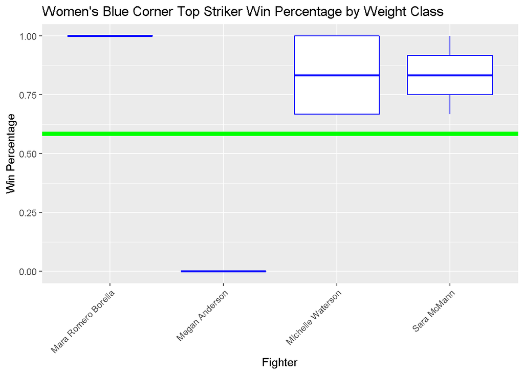

```r
# Creates two boxplots reflecting women's data for red and blue corners. The fighters with the best strikes landed percentage are shown on the x-axis and their corresponding win percentage is on the y-axis. The red line show the average win percentage for all fighters.

WB_strike_plot <- F_data %>% filter(B_fighter %in% c("Megan Anderson", "Mara Romero Borella",
                                                     "Michelle Waterson", "Sara McMann")) %>%
                                                      select(B_fighter, B_win_pct)

ggplot(WB_strike_plot) + geom_boxplot(aes(x = B_fighter, y = B_win_pct), color = "blue") +
  theme(axis.text.x=element_text(angle=45,hjust=1)) +
  ggtitle("Women's Blue Corner Top Striker Win Percentage by Weight Class") +
  xlab("Fighter") + ylab("Win Percentage") + geom_hline(yintercept = 0.585089, color = "green", size = 2)
```

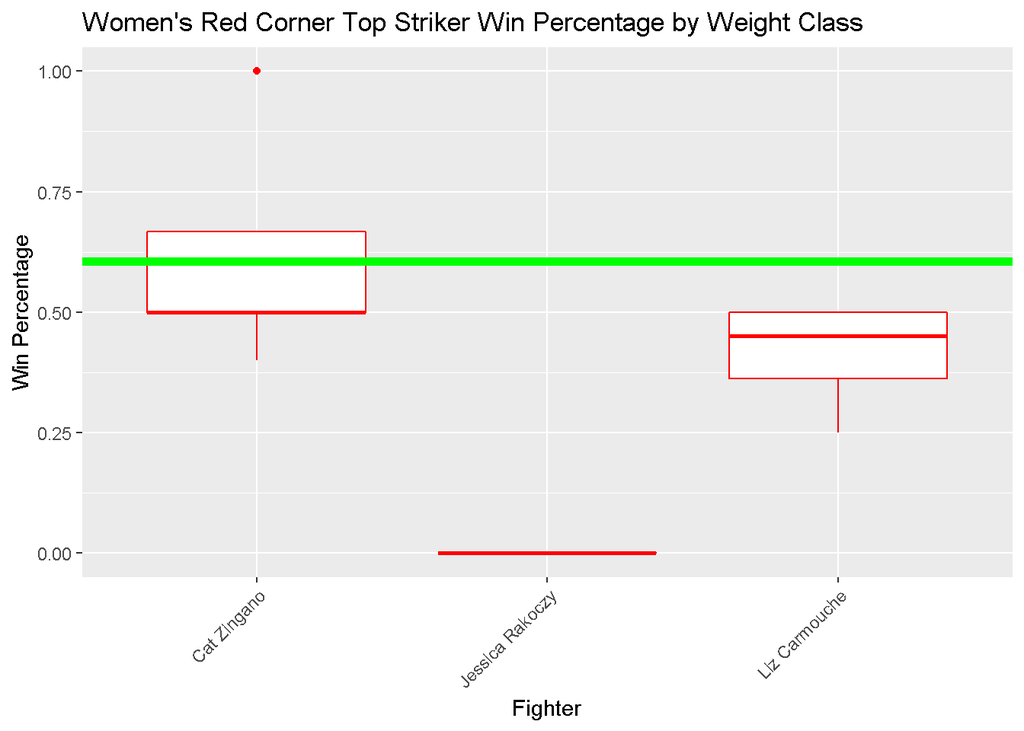

```r
WR_strike_plot <- F_data %>% filter(R_fighter %in% c("Liz Carmouche", "Cat Zingano", "Jessica Rakoczy")) %>%
  select(R_fighter, R_win_pct)

ggplot(WR_strike_plot) + geom_boxplot(aes(x = R_fighter, y = R_win_pct), color = "red") +
  theme(axis.text.x=element_text(angle=45,hjust=1)) +
  ggtitle("Women's Red Corner Top Striker Win Percentage by Weight Class") +
  xlab("Fighter") + ylab("Win Percentage") + geom_hline(yintercept = 0.6062128, color = "green", size = 2)
```

# Summary